# Data Visualization seaborn

Seaborn is one of an amazing library for visualization of the graphical statistical plotting in Python. Seaborn provides many color palettes and defaults beautiful styles to make the creation of many statistical plots in Python more attractive

## Objective of Python Seaborn library

Seaborn library aims to make a more attractive visualization of the central part of understanding and exploring data. It is built on the core of the matplotlib library and also provides dataset-oriented APIs Tutorial Overview

### What is Seaborn and how/why it's used

We always have a large amount of data, or we may have some applications which deal with the large data, so in order to represent our data in a good way, we may require some library which can be able to represent our data that is begin stored in a table, array, list, and other data structure efficiently. So seaborn is the library which can represent our data stored in an array, list o any other data structure in a graphical form, which helps users and developers to get more clarity of data if we need to handle large data in our application.

- Trend Plots:
1. Line Plots
- Summary Plots:
1. Bar Plots
2. count plot
- Distribution of Data:
1. Histogram
2. Box Plots
- Relationship Plots
1. Scatter Plots
- lmplot (combo of regplot() and FacetGrid)
- Holistic views / Combo:
1. Sub Plots
2. Pair Plots
3. Join Plots
- Correlation / Relationships:
1. Heat Maps

```python
# Packages / libraries
import os
import numpy as np
import pandas as pd
from matplotlib import pyplot as plt
import matplotlib.pyplot as plt
import seaborn as sns
%matplotlib inline
```

```python
#import csv file
data = pd.read_csv("C:/Users/deepak kumar/Desktop/Employee Database.csv")
data
```

|  | id | gender | bdate | educ | jobcat | salary | salbegin | jobtime | prevexp | minority |
| --- | --- | --- | --- | --- | --- | --- | --- | --- | --- | --- |
| 0 | 1 | Male | 3-Feb-52 | 15 | Manager | 57000 | 27000 | 98 | 144 | No |
| 1 | 2 | Male | 23-May-58 | 16 | Clerical | 40200 | 18750 | 98 | 36 | No |
| 2 | 3 | Female | 26-Jul-29 | 12 | Clerical | 21450 | 12000 | 98 | 381 | No |
| 3 | 4 | Female | 15-Apr-47 | 8 | Clerical | 21900 | 13200 | 98 | 190 | No |
| 4 | 5 | Male | 9-Feb-55 | 15 | Clerical | 45000 | 21000 | 98 | 138 | No |
| ... | ... | ... | ... | ... | ... | ... | ... | ... | ... | ... |
| 469 | 470 | Male | 22-Jan-64 | 12 | Clerical | 26250 | 15750 | 64 | 69 | Yes |
| 470 | 471 | Male | 3-Aug-66 | 15 | Clerical | 26400 | 15750 | 64 | 32 | Yes |
| 471 | 472 | Male | 21-Feb-66 | 15 | Clerical | 39150 | 15750 | 63 | 46 | No |
| 472 | 473 | Female | 25-Nov-37 | 12 | Clerical | 21450 | 12750 | 63 | 139 | No |
| 473 | 474 | Female | 5-Nov-68 | 12 | Clerical | 29400 | 14250 | 63 | 9 | No |

474 rows × 10 columns

```python
data1 =pd.read_csv("C:/Users/deepak kumar/Desktop/Marketing Raw.csv")
data1
```

|  | Date | Week | Week_ID | Month | Month_ID | Year | Day_Name | Visitors | Revenue | Marketing Spend | Promo |
| --- | --- | --- | --- | --- | --- | --- | --- | --- | --- | --- | --- |
| 0 | 2020-09-11 | 46 | 34 | 11 | 11 | 2020 | Monday | 707 | 465 | 651.375000 | No Promo |
| 1 | 2020-10-11 | 46 | 34 | 11 | 11 | 2020 | Tuesday | 1455 | 10386 | 1298.250000 | Promotion Red |
| 2 | 2020-11-11 | 46 | 34 | 11 | 11 | 2020 | Wednesday | 1520 | 12475 | 1559.375000 | Promotion Blue |
| 3 | 2020-12-11 | 46 | 34 | 11 | 11 | 2020 | Thursday | 1726 | 11712 | 1801.750000 | No Promo |
| 4 | 13/11/2020 | 46 | 34 | 11 | 11 | 2020 | Friday | 2134 | 10000 | 2614.500000 | No Promo |
| ... | ... | ... | ... | ... | ... | ... | ... | ... | ... | ... | ... |
| 177 | 2021-05-05 | 19 | 60 | 5 | 17 | 2021 | Wednesday | 1400 | 7284 | 1119.600000 | No Promo |
| 178 | 2021-06-05 | 19 | 60 | 5 | 17 | 2021 | Thursday | 2244 | 13021 | 2067.888889 | Promotion Red |
| 179 | 2021-07-05 | 19 | 60 | 5 | 17 | 2021 | Friday | 2023 | 4587 | 1450.200000 | No Promo |
| 180 | 2021-08-05 | 19 | 60 | 5 | 17 | 2021 | Saturday | 1483 | 5927 | 1121.875000 | No Promo |
| 181 | 2021-09-05 | 20 | 61 | 5 | 17 | 2021 | Sunday | 1303 | 3861 | 871.000000 | No Promo |

182 rows × 11 columns

```python
data.info()
data1.info()
```

```
<class 'pandas.core.frame.DataFrame'>
RangeIndex: 474 entries, 0 to 473
Data columns (total 10 columns):
 #   Column    Non-Null Count  Dtype
---  ------    --------------  -----
 0   id        474 non-null    int64
 1   gender    474 non-null    object
 2   bdate     474 non-null    object
 3   educ      474 non-null    int64
 4   jobcat    474 non-null    object
 5   salary    474 non-null    int64
 6   salbegin  474 non-null    int64
 7   jobtime   474 non-null    int64
 8   prevexp   474 non-null    object
 9   minority  474 non-null    object
dtypes: int64(5), object(5)
memory usage: 37.2+ KB
<class 'pandas.core.frame.DataFrame'>
RangeIndex: 182 entries, 0 to 181
Data columns (total 11 columns):
 #   Column           Non-Null Count  Dtype
---  ------           --------------  -----
 0   Date             182 non-null    object
 1   Week             182 non-null    int64
 2   Week_ID          182 non-null    int64
 3   Month            182 non-null    int64
 4   Month_ID         182 non-null    int64
 5   Year             182 non-null    int64
 6   Day_Name         182 non-null    object
 7   Visitors         182 non-null    int64
 8   Revenue          182 non-null    int64
 9   Marketing Spend  182 non-null    float64
 10  Promo            182 non-null    object
dtypes: float64(1), int64(7), object(3)
memory usage: 15.8+ KB
```

# Line Graph

A line graph is a pictorial representation of information which changes continuously over time. A line graph can also be referred to as a line chart. Within a line graph, there are points connecting the data to show the continuous change. The lines in a line graph can move up and down based on the data. We can use a line graph to compare different events, information, and situations.

# What is a line graph used for

# How do you make a line graph?

To make a linear/line graph, follow the below steps:

1. Observe the data from the data-table to choose a suitable scale.
2. Draw and label the scale on x and y axes, i.e. the horizontal and vertical axes, respectively.
3. List each item and place the points (taking x-value as the x-coordinate and y-value as the y-coordinate) on the graph.
4. Finally, join the plotted points with line segments to get a line chart. # How does a line graph work? A line graph helps understand the performance or comparisons over time by observing the line’s steepness on a graph sheet. # What are the five parts of a line graph?
5. Title
6. Scale
7. Labels
8. Bars
9. Data values

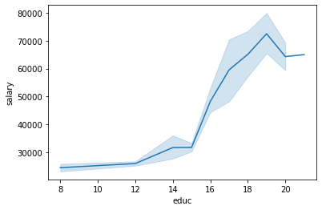

```python
#investigate the salary by educ
ln =sns.lineplot(x = 'educ',y = 'salary',data=data )
```

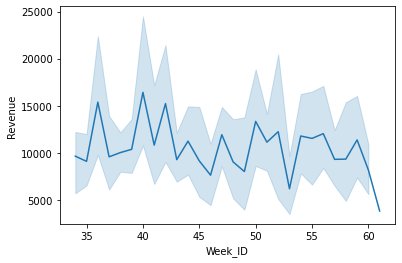

```python
#investigate the Revenue by Week_ID
ln =sns.lineplot(x = 'Week_ID',y = 'Revenue',data=data1)
```

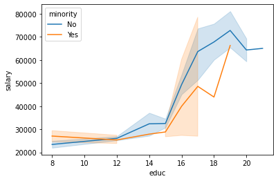

```python
#adding categories
ln =sns.lineplot(x = 'educ',y = 'salary',data=data,hue='minority' )
```

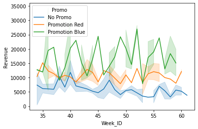

```python
ln =sns.lineplot(x = 'Week_ID',y = 'Revenue',data=data1,hue='Promo')
```

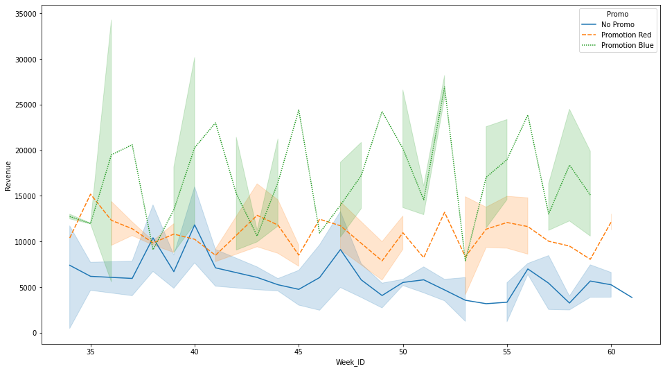

```python
#adding categories
#increace the size and style
plt.figure(figsize = (16,9))
ln =sns.lineplot(x = 'Week_ID',y = 'Revenue',data=data1,hue='Promo',style='Promo')
```

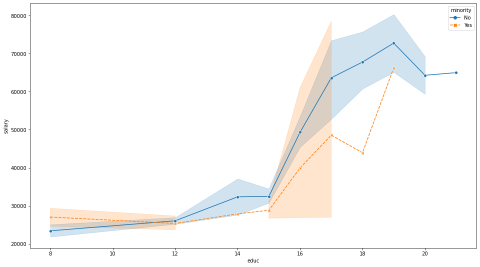

```python
#adding categories
#increace the size and style
plt.figure(figsize = (16,9))
ln =sns.lineplot(x = 'educ',y = 'salary',data=data,hue='minority', style='minority',markers=True)
```

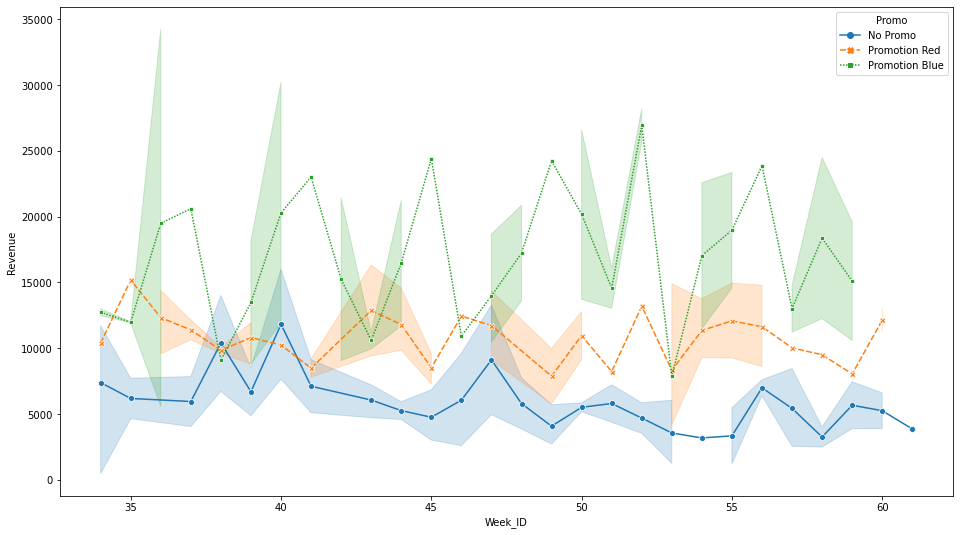

```python
plt.figure(figsize = (16,9))
ln =sns.lineplot(x = 'Week_ID',y = 'Revenue',data=data1,hue='Promo',style='Promo',markers=True)
```

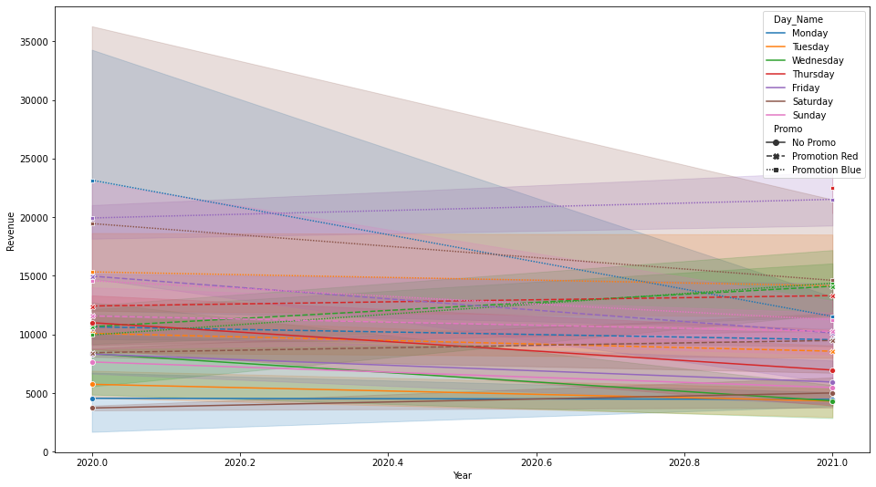

```python
plt.figure(figsize = (16,9))
ln =sns.lineplot(x = 'Year',y = 'Revenue',data=data1,hue='Day_Name',style='Promo',markers=True)
```

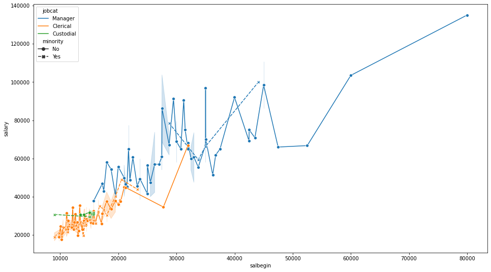

```python
plt.figure(figsize = (16,9))
ln =sns.lineplot(x = 'salbegin',y = 'salary',data=data,hue='jobcat', style='minority',markers=True)
```

# Bar plot

Bar Graph Definition The pictorial representation of a grouped data, in the form of vertical or horizontal rectangular bars, where the lengths of the bars are equivalent to the measure of data, are known as bar graphs or bar charts. The three major attributes of bar graphs are:

# The bar graph helps to compare the different sets of data among different groups easily.

1. The bar graph helps to compare the different sets of data among different groups easily.
2. It shows the relationship using two axes, in which the categories on one axis and the discrete values on the other axis.
3. The graph shows the major changes in data over time. # Uses of Bar Graphs Bar graphs are used to match things between different groups or to trace changes over time. Yet, when trying to estimate change over time, bar graphs are most suitable when the changes are bigger. # Properties of Bar Graph
4. Some of the important properties of a bar graph are as follows:
5. All the bars should have a common base.
6. Each column in the bar graph should have equal width.
7. The height of the bar should correspond to the data value.
8. The distance between each bar should be the same. # The types of bar charts are as follows:
9. Vertical bar chart
10. Horizontal bar chart
- When the grouped data are represented vertically in a graph or chart with the help of bars, where the bars denote the measure of data, such graphs are called vertical bar graphs. The data is represented along the y-axis of the graph, and the height of the bars shows the values.
- When the grouped data are represented horizontally in a chart with the help of bars, then such graphs are called horizontal bar graphs, where the bars show the measure of data. The data is depicted here along the x-axis of the graph, and the length of the bars denote the values.

| minority | salary |
| --- | --- |
| No | 13328625 |
| Yes | 2986250 |

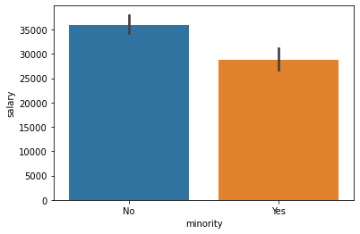

```python
#total salary by minority
sns.barplot(x='minority',y='salary',data=data)
data[['salary','minority']].groupby("minority").agg({'salary':'sum'})
```

| jobcat | salary |
| --- | --- |
| Clerical | 27838.539945 |
| Custodial | 30938.888889 |
| Manager | 63977.797619 |

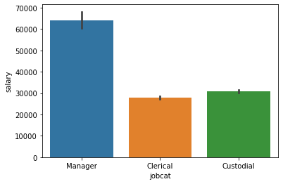

```python
#total salary by jobcat
sns.barplot(x='jobcat',y='salary',data=data)
data[['salary','jobcat']].groupby("jobcat").agg({'salary':'mean'})
```

| prevexp | salary |
| --- | --- |
| 10 | 42366.666667 |
| 101 | 27450.000000 |
| 102 | 25275.000000 |
| 103 | 42300.000000 |
| 105 | 26550.000000 |
| ... | ... |
| 94 | 33900.000000 |
| 96 | 39475.000000 |
| 97 | 25125.000000 |
| 99 | 66250.000000 |
| missing | 22781.250000 |

208 rows × 1 columns

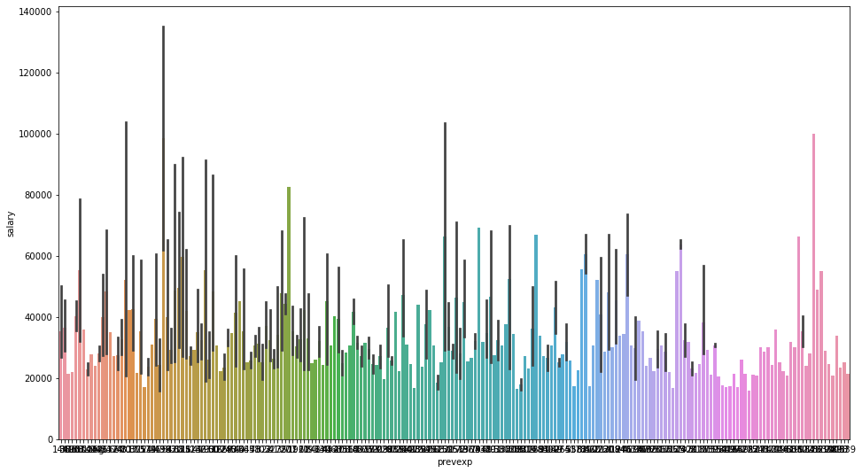

```python
plt.figure(figsize = (16,9))
sns.barplot(x='prevexp',y='salary',data=data)
data[['salary','prevexp']].groupby("prevexp").agg({'salary':'mean'})
```

| Month_ID | Revenue |
| --- | --- |
| 11 | 11255.454545 |
| 12 | 11667.806452 |
| 13 | 9588.516129 |
| 14 | 10683.892857 |
| 15 | 10555.354839 |
| 16 | 10806.500000 |
| 17 | 7636.000000 |

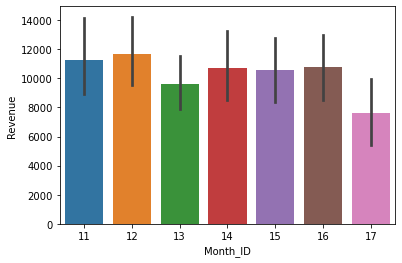

```python
#total Revenue by month month_id
sns.barplot(x='Month_ID',y='Revenue',data=data1)
data1[['Revenue','Month_ID']].groupby("Month_ID").agg({'Revenue':'mean'})
```

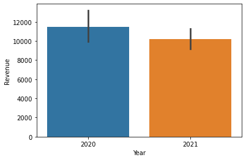

```python
#total Revenue by year
sns.barplot(x='Year',y='Revenue',data=data1)
```

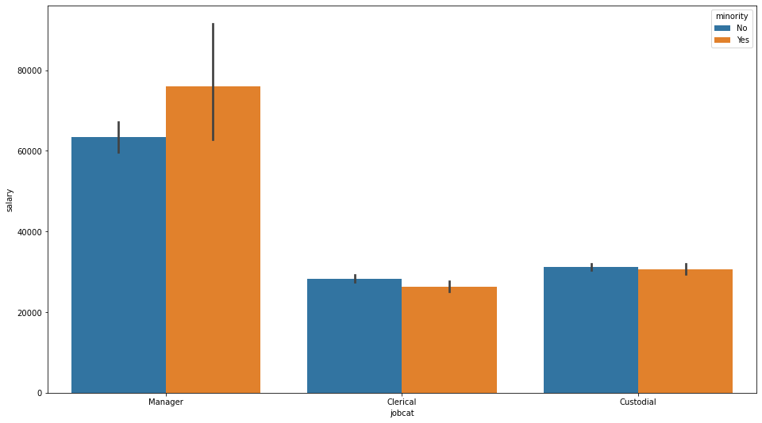

```python
#total salary by jobcat and put the hue = minority
plt.figure(figsize = (16,9))
sns.barplot(x='jobcat',y='salary',data=data,hue='minority')
```

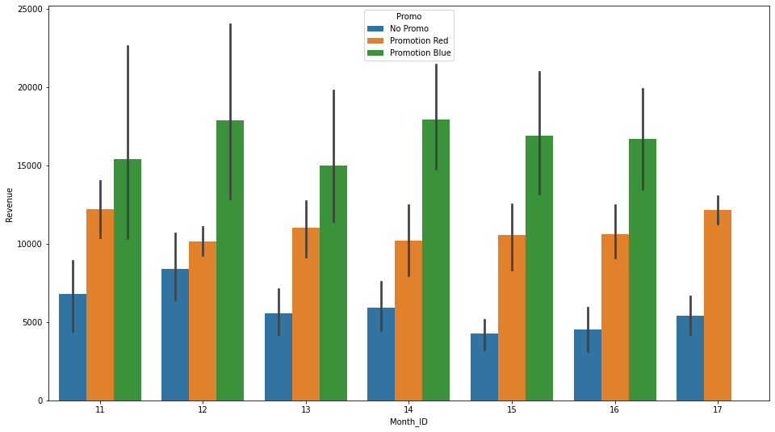

```python
#total Revenue by Month_ID and put the hue = Promo
plt.figure(figsize = (16,9))
sns.barplot(x='Month_ID',y='Revenue',data=data1,hue='Promo')
```

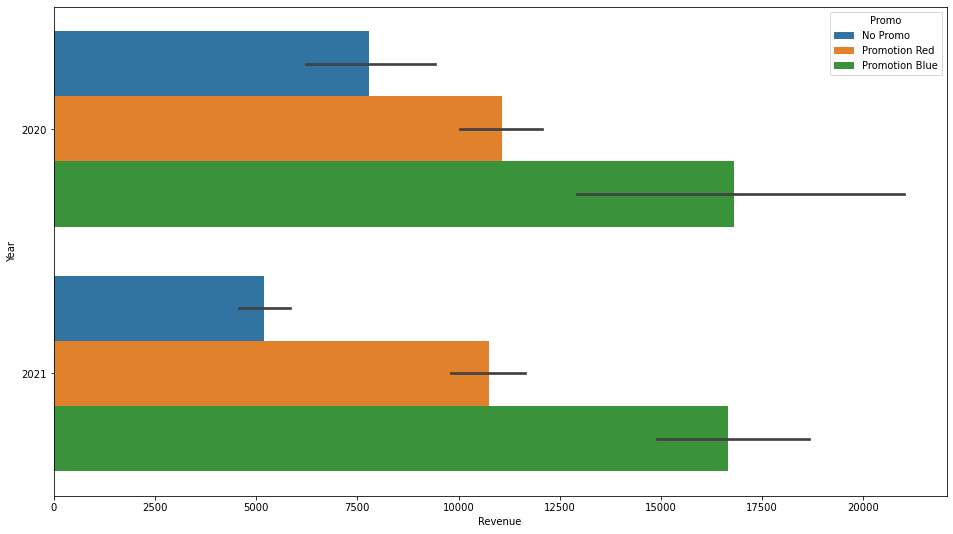

```python
#change the orient in Horizontal
plt.figure(figsize = (16,9))
sns.barplot(x='Revenue',y='Year',data=data1,hue='Promo',orient='h')
```

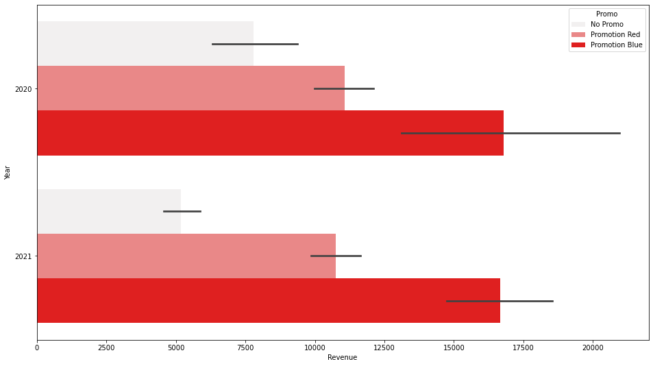

```python
#change the colours of the bar
plt.figure(figsize = (16,9))
sns.barplot(x='Revenue',y='Year',data=data1,hue='Promo',orient='h',color='red')
```

# histogram

A histogram graph is a graph that is used to visualize the frequency of discrete and continuous data using rectangular bars. The rectangular bars show the number of data points that fall into a specified class interval. Also known as a histogram chart, the class intervals (or bins) are not always of equal size across the horizontal axis.

# When to Use Histogram

The histogram graph is used under certain conditions. They are:

1. The data should be numerical.
2. A histogram is used to check the shape of the data distribution.
3. Used to check whether the process changes from one period to another.
4. Used to determine whether the output is different when it involves two or more processes.
5. Used to analyse whether the given process meets the customer requirements

# How to Make Histogram?

You need to follow the below steps to construct a histogram.

1. Begin by marking the class intervals on the X-axis and frequencies on the Y-axis.
2. The scales for both the axes have to be the same.
3. Class intervals need to be exclusive.
4. Draw rectangles with bases as class intervals and corresponding frequencies as heights.
5. A rectangle is built on each class interval since the class limits are marked on the horizontal axis, and the frequencies are indicated on the vertical axis.
6. The height of each rectangle is proportional to the corresponding class frequency if the intervals are equal.
7. The area of every individual rectangle is proportional to the corresponding class frequency if the intervals are unequal.

# Difference Between Histogram And Bar Graph

1. It is a two-dimensional figure
2. The frequency is shown by the area of each rectangle
3. It shows rectangles touching each other
- Bar
1. It is a one-dimensional figure
2. The height shows the frequency and the width has no significance.
3. It consists of rectangles separated from each other with equal spaces.

```python
x = data['salary'].values
x
```

[output not shown]

[output cut: 45 more lines]

[output not shown]

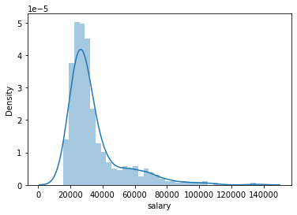

```python
# see the salary of tips data
sns.distplot(data["salary"])
```

[output not shown]

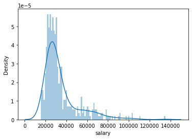

```python
#bins  means you can show the particualr bar like 1 to five 10 to 50...n # i divided the bar into 80
sns.distplot(data["salary"],bins =100)
```

[output not shown]

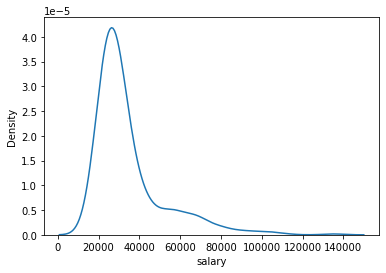

```python
# use hist = false - means if you should not need distplot then we can use hist
sns.distplot(data["salary"],hist =False)
```

[output not shown]

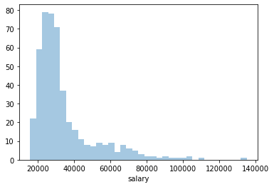

```python
#kde = false use  - kde means just show the hist it would be  not kde
sns.distplot(data["salary"],kde =False)
```

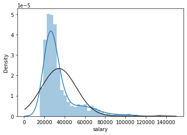

```python
# use fit - mean if you want to see the normilazation of the data so we willl use double kde
from scipy.stats import norm
sns.distplot(data["salary"],fit =norm)
```

[output not shown]

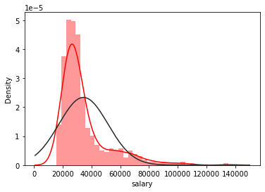

```python
#change the colours of the the graph
sns.distplot(data["salary"],fit =norm,color="r")
```

[output not shown]

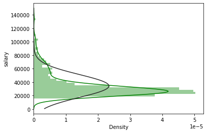

```python
sns.distplot(data["salary"],fit =norm,color='g',vertical=True)
```

```python
#calculate the mean in the data set
mean =data['salary'].mean()
mean
```

```
34419.56751054852
```

[output not shown]

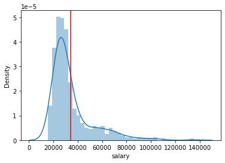

```python
sns.distplot(data["salary"])
plt.axvline(mean,0,1,color='red')
```

[output not shown]

# count plot

The countplot is used to represent the occurrence(counts) of the observation present in the categorical variable.

1. x and y- This parameter specifies the data we refer to for representation and then observes the highlighted patterns.
2. color- This parameter specifies the color that can give a good appearance to our plot.
3. palette- It takes the value of the palette. It is mostly used to show the hue variable.
4. hue- This parameter specifies the column name.
5. data- This parameter specifies the data frame we would like to take for the representation. For instance, data can be an array.
6. dodge- This parameter is an optional one and it accepts a Boolean value as input.
7. saturation- This parameter accepts a float value. A variation in the intensity of colors can be observed when we specify this.
8. hue_order- The parameter hue_order takes strings as an input.
9. kwargs- The parameter kwargs specifies the key and value mappings.
10. ax- The parameter ax is an optional one and is used to take axes on which plots are created.
11. orient- The parameter orient is an optional one and tells the orientation of the plot that we need, horizontal or vertical.

```python
data['gender'].value_counts()
```

```
Male      258
Female    216
Name: gender, dtype: int64
```

[output not shown]

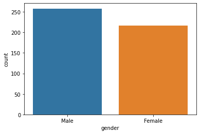

```python
# draw the count plot with the help of gender columns
sns.countplot('gender',data=data)
```

```python
data['jobcat'].value_counts()
```

```
Clerical     363
Manager       84
Custodial     27
Name: jobcat, dtype: int64
```

[output not shown]

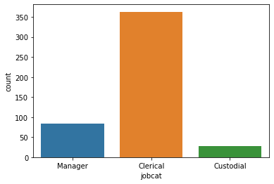

```python
sns.countplot('jobcat',data=data)
```

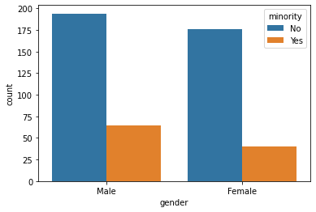

```python
sns.countplot(x='gender',data=data,hue='minority')
```

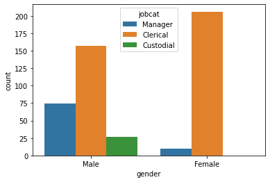

```python
sns.countplot(x='gender',data=data,hue='jobcat')
```

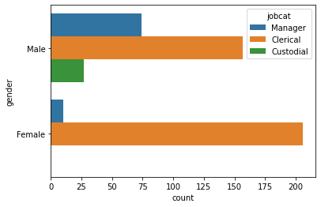

```python
sns.countplot(y='gender',data=data,hue='jobcat')
```

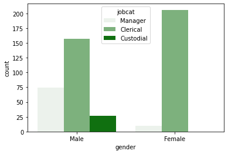

```python
sns.countplot(x='gender',data=data,hue='jobcat',color='green')
```